# Trending YouTube Video Sentimental and Statistical Analysis Using R

ASHIKA PULLOLICKAL JOHN

14 June 2019

- **YouTube** is an American video-sharing website headquartered in San Bruno, California. The service was created by three former PayPal employees—Chad Hurley, Steve Chen, and Jawed Karim—in February 2005. Google bought the site in November 2006 for US$1.65 billion; YouTube now operates as one of Google’s subsidiaries.

## Loading the requires libraries

```r
library(rmarkdown)
library(rjson)
library(jsonlite)
library(pander)
library(cowplot)
library(tidyverse)
library(magrittr)
library(dplyr)
library(treemap)
library(scales)
library(ggplot2)
library(gplots)
library(tm)
library(SnowballC)
library(RSentiment)
```

# Data manipulation

```r
library(data.table)
library(dplyr)
library(DT)
```

# Time manipulation

```r
library(lubridate)
```

# Visualization

```r
library(RColorBrewer)
library(plotrix)
library(corrplot)
library(ggdendro)
library(ggrepel)
```

# Wordcloud

```r
library(wordcloud)
```

# Text manipulation

```r
library(tidytext)
library(stringr)
library(tm)
library(sentimentr)
library(RSentiment)
```

## Loading the Data

```r
usv = read.csv("USvideos.csv")
cav = read.csv("CAvideos.csv")
gbv = read.csv("GBvideos.csv")
frv = read.csv("FRvideos.csv")
gev = read.csv("DEvideos.csv")
```

# Reading and preparing data

```r
gb <- tail(fread("GBvideos.csv",encoding = "UTF-8"),20000)
gb[,"Location":="GB"]

fr <- tail(fread("FRvideos.csv",encoding = "UTF-8"),20000)
fr[,"Location":="FR"]

ca <- tail(fread("CAvideos.csv",encoding = "UTF-8"),20000)
ca[,"Location":="CA"]

us <- tail(fread("USvideos.csv",encoding = "UTF-8"),20000)
us[,"Location":="US"]

de <- tail(fread("DEvideos.csv",encoding = "UTF-8"),20000)
de[,"Location":="DE"]

videos <- as.data.table(rbind(gb,fr,ca,us,de))
videos$trending_date <- ydm(videos$trending_date)
videos$publish_time <- ymd(substr(videos$publish_time,start = 1,stop = 10))
videos$dif_days <- videos$trending_date-videos$publish_time
```

## First lets see the CORRELATION

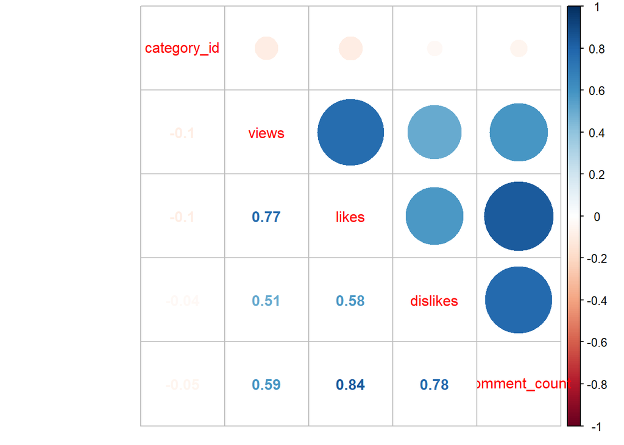

```r
corrplot.mixed(corr = cor(videos[,c("category_id","views","likes","dislikes","comment_count"),with=F]))
```

### MOST…

## Viewed videos

```r
mvideo <- videos[,.("Total_Views"=round(max(views,na.rm = T),digits = 2)),by=.(title,thumbnail_link)][order(-Total_Views)]

mvideo %>%

  mutate(image = paste0('<img width="80%" height="80%" src="', thumbnail_link , '"></img>')) %>%

  arrange(-Total_Views) %>%

  top_n(10,wt = Total_Views) %>%

  select(image, title, Total_Views) %>%

  datatable(class = "nowrap hover row-border", escape = FALSE, options = list(dom = 't',scrollX = TRUE, autoWidth = TRUE))
```

|  | image | title | Total_Views |
| --- | --- | --- | --- |
| 1 |  | To Our Daughter | 44818108 |
| 2 |  | Nicky Jam x J. Balvin - X (EQUIS) \| Video Oficial \| Prod. Afro Bros & Jeon | 40567774 |
| 3 |  | Marvel Studios' Avengers: Infinity War - Official Trailer | 39980116 |
| 4 |  | Taylor Swift - End Game ft. Ed Sheeran, Future | 34708457 |
| 5 |  | Ed Sheeran - Perfect (Official Music Video) | 33523622 |
| 6 |  | Ariana Grande - No Tears Left To Cry | 32331284 |
| 7 |  | Nicky Jam x J. Balvin - X (EQUIS) \| Video Oficial | 30686233 |
| 8 |  | Taylor Swift - Delicate | 29923522 |
| 9 |  | Lil Pump - ESSKEETIT (Official Music Video) | 28997182 |
| 10 |  | Drake - God’s Plan | 28866802 |

## Liked videos (Absolute)

```r
mvideo <- videos[,.("Total_Likes"=round(max(likes,na.rm = T),digits = 2)),by=.(title,thumbnail_link)][order(-Total_Likes)]



mvideo %>%

  mutate(image = paste0('<img width="80%" height="80%" src="', thumbnail_link , '"></img>')) %>%

  arrange(-Total_Likes) %>%

  top_n(10,wt = Total_Likes) %>%

  select(image, title, Total_Likes) %>%

  datatable(class = "nowrap hover row-border", escape = FALSE, options = list(dom = 't',scrollX = TRUE, autoWidth = TRUE))
```

|  | image | title | Total_Likes |
| --- | --- | --- | --- |
| 1 |  | j-hope 'Daydream (백일몽)' MV | 2392595 |
| 2 |  | Drake - God’s Plan | 1997355 |
| 3 |  | Ariana Grande - No Tears Left To Cry | 1890564 |
| 4 |  | Suicide: Be Here Tomorrow. | 1782258 |
| 5 |  | Taylor Swift - End Game ft. Ed Sheeran, Future | 1681449 |
| 6 |  | Ed Sheeran - Perfect (Official Music Video) | 1634130 |
| 7 |  | BTS (방탄소년단) 'Euphoria : Theme of LOVE YOURSELF 起 Wonder' | 1573030 |
| 8 |  | Lil Pump - ESSKEETIT (Official Music Video) | 1461135 |
| 9 |  | Marvel Studios' Avengers: Infinity War - Official Trailer | 1420090 |
| 10 |  | j-hope 'Airplane' MV | 1401947 |

## Disliked videos (Absolute)

```r
mvideo <- videos[,.("Total_Dislikes"=round(max(dislikes,na.rm = T),digits = 2)),by=.(title,thumbnail_link)][order(-Total_Dislikes)]



mvideo %>%

  mutate(image = paste0('<img width="80%" height="80%" src="', thumbnail_link , '"></img>')) %>%

  arrange(-Total_Dislikes) %>%

  top_n(10,wt = Total_Dislikes) %>%

  select(image, title, Total_Dislikes) %>%

  datatable(class = "nowrap hover row-border", escape = FALSE, options = list(dom = 't',scrollX = TRUE, autoWidth = TRUE))
```

|  | image | title | Total_Dislikes |
| --- | --- | --- | --- |
| 1 |  | Suicide: Be Here Tomorrow. | 398361 |
| 2 |  | Jake Paul - Saturday Night (Song) feat. Nick Crompton & Chad Tepper (Official Music Video) | 167908 |
| 3 |  | Fergie Performs The U.S. National Anthem / 2018 NBA All-Star Game | 117128 |
| 4 |  | Lil Pump - ESSKEETIT (Official Music Video) | 112987 |
| 5 |  | Shakira - Trap (Official Video) ft. Maluma | 98637 |
| 6 |  | Taylor Swift - End Game ft. Ed Sheeran, Future | 91764 |
| 7 |  | Saad Lamjarred - Ghazali (EXCLUSIVE Music Video) \| 2018 \| سعد لمجرد - غزالي ( فيديو كليب حصرياً) | 82564 |
| 8 |  | Taylor Swift - Delicate | 76072 |
| 9 |  | Ariana Grande - No Tears Left To Cry | 64058 |
| 10 |  | J. Balvin, Jeon, Anitta - Machika | 55803 |

## Commented videos (Absolute)

```r
mvideo <- videos[,.("Total_comments"=round(max(comment_count,na.rm = T),digits = 2)),by=.(title,thumbnail_link)][order(-Total_comments)]



mvideo %>%

  mutate(image = paste0('<img width="80%" height="80%" src="', thumbnail_link , '"></img>')) %>%

  arrange(-Total_comments) %>%

  top_n(10,wt = Total_comments) %>%

  select(image, title, Total_comments) %>%

  datatable(class = "nowrap hover row-border", escape = FALSE, options = list(dom = 't',scrollX = TRUE, autoWidth = TRUE))
```

|  | image | title | Total_comments |
| --- | --- | --- | --- |
| 1 |  | Suicide: Be Here Tomorrow. | 611327 |
| 2 |  | j-hope 'Daydream (백일몽)' MV | 437036 |
| 3 |  | BTS (방탄소년단) 'Euphoria : Theme of LOVE YOURSELF 起 Wonder' | 180262 |
| 4 |  | Marvel Studios' Avengers: Infinity War - Official Trailer | 177598 |
| 5 |  | Ariana Grande - No Tears Left To Cry | 176926 |
| 6 |  | Lil Pump - ESSKEETIT (Official Music Video) | 161259 |
| 7 |  | j-hope 'Airplane' MV | 158127 |
| 8 |  | Taylor Swift - End Game ft. Ed Sheeran, Future | 141243 |
| 9 |  | Taylor Swift - Delicate | 133691 |
| 10 |  | Drake - God’s Plan | 131284 |

# Top 10 in percentage

- Because the absolute number of likes, dislikes and comments didnt show all the information to really know if the video had an impact or not we will see their percentages.

## % Liked videos

```r
mvideo <- videos[,.("Percentage_Likes"=round(100*max(likes,na.rm = T)/max(views,na.rm = T),digits = 2)),by=.(title,thumbnail_link)][order(-Percentage_Likes)]



mvideo %>%

  mutate(image = paste0('<img width="80%" height="80%" src="', thumbnail_link , '"></img>')) %>%

  arrange(-Percentage_Likes) %>%

  top_n(10,wt = Percentage_Likes) %>%

  select(image, title, Percentage_Likes) %>%

  datatable(class = "nowrap hover row-border", escape = FALSE, options = list(dom = 't',scrollX = TRUE, autoWidth = TRUE))
```

|  | image | title | Percentage_Likes |
| --- | --- | --- | --- |
| 1 |  | Nigthcore ( Spécial 3M ) - Burn | 40.6 |
| 2 |  | NUMBERS - Épisode 1 | 31.61 |
| 3 |  | J'ENLÈVE MON MASQUE CONTRE DE L'ARGENT ?! | 30.86 |
| 4 |  | LA HOTLINE D'EN MARCHE - Le Bon Sens | 30.57 |
| 5 |  | [VOSTFR] JIMIN SE SENT MAL CAR UN OISEAU A PERDU SA PATTE ;-; | 29.75 |
| 6 |  | #FANTAXYOU2 GUNTER L'ALLEMAND ! | 29.63 |
| 7 |  | JE SUIS DE RETOUR, JE TE JURE. | 28.3 |
| 8 |  | Je suis trans | 28.27 |
| 9 |  | LA DATE OFFICIELLE DE LA SORTIE DE LA HIXTAPE ! (#HixtapeisComing) | 27.79 |
| 10 |  | [MIXTAPE] I.M - Fly With Me (Teaser) | 27.63 |

## % Disliked videos

```r
mvideo <- videos[,.("Percentage_Dislikes"=round(100*max(dislikes,na.rm = T)/max(views,na.rm = T),digits = 2)),by=.(title,thumbnail_link)][order(-Percentage_Dislikes)]



mvideo %>%

  mutate(image = paste0('<img width="80%" height="80%" src="', thumbnail_link , '"></img>')) %>%

  arrange(-Percentage_Dislikes) %>%

  top_n(10,wt = Percentage_Dislikes) %>%

  select(image, title, Percentage_Dislikes) %>%

  datatable(class = "nowrap hover row-border", escape = FALSE, options = list(dom = 't',scrollX = TRUE, autoWidth = TRUE))
```

|  | image | title | Percentage_Dislikes |
| --- | --- | --- | --- |
| 1 |  | LES PROPHÉTIES DE JEAN XXIII : La Fin Des Temps pour 2033 - Avril 2018 | 25.39 |
| 2 |  | SORTEZ-MOI DE LA RUE - JOUR 10 | 12.83 |
| 3 |  | How To Make Money Online With Mobile/Tablet ( Make Money By Installing Apps ) | 8.11 |
| 4 |  | LE PARANORMAL DU 24 : L'AVENIR de la CHAINE est entre vos mains!!! | 7.57 |
| 5 |  | Son costume a craqué en plein Dame Tu Cosita challenge... ಠ_ಠ | 7.16 |
| 6 |  | 5 MAI CNT L'après | 5.9 |
| 7 |  | CNT 5 MAI Tous unis ! | 5.78 |
| 8 |  | Cet enfant n’a pas survécu à cette vague… | 5.16 |
| 9 |  | UNE FAUSSE PSP PIRE QUE L'ANCIENNE | 5.11 |
| 10 |  | Pourquoi LES ANIMAUX FANTASTIQUES c'est DE LA MERDE | 4.86 |

## % Commented videos

```r
mvideo <- videos[,.("Percentage_comments"=round(100*max(comment_count,na.rm = T)/max(views,na.rm = T),digits = 2)),by=.(title,thumbnail_link)][order(-Percentage_comments)]



mvideo %>%

  mutate(image = paste0('<img width="80%" height="80%" src="', thumbnail_link , '"></img>')) %>%

  arrange(-Percentage_comments) %>%

  top_n(10,wt = Percentage_comments) %>%

  select(image, title, Percentage_comments) %>%

  datatable(class = "nowrap hover row-border", escape = FALSE, options = list(dom = 't',scrollX = TRUE, autoWidth = TRUE))
```

|  | image | title | Percentage_comments |
| --- | --- | --- | --- |
| 1 |  | ...❤ | 41.37 |
| 2 |  | NOUVEAUX CONCOURS GAGNE TON KITS SLIMES, SLIME LICORNE, PÂTES A MODELER FOAM, ... | 25.02 |
| 3 |  | 1er débat Athée/Musulman francophone : Karim al-Hanifi & Jean Bricmont, 2018 à partager ! | 16.91 |
| 4 |  | CONCOURS NOUVEAUTÉS w/Graine Créative ! | 15.97 |
| 5 |  | JE T'AIME... | 14.55 |
| 6 |  | MON CODE AMI \| NINTENDO SWITCH | 14.3 |
| 7 |  | LE PARANORMAL DU 24 : L'AVENIR de la CHAINE est entre vos mains!!! | 13.88 |
| 8 |  | FAQ | 12.87 |
| 9 |  | La vitre était trop fine... | 12.78 |
| 10 |  | Jeanne d'Arc peut-elle être noire ? | 12.78 |

# Top trending Channels in all countries

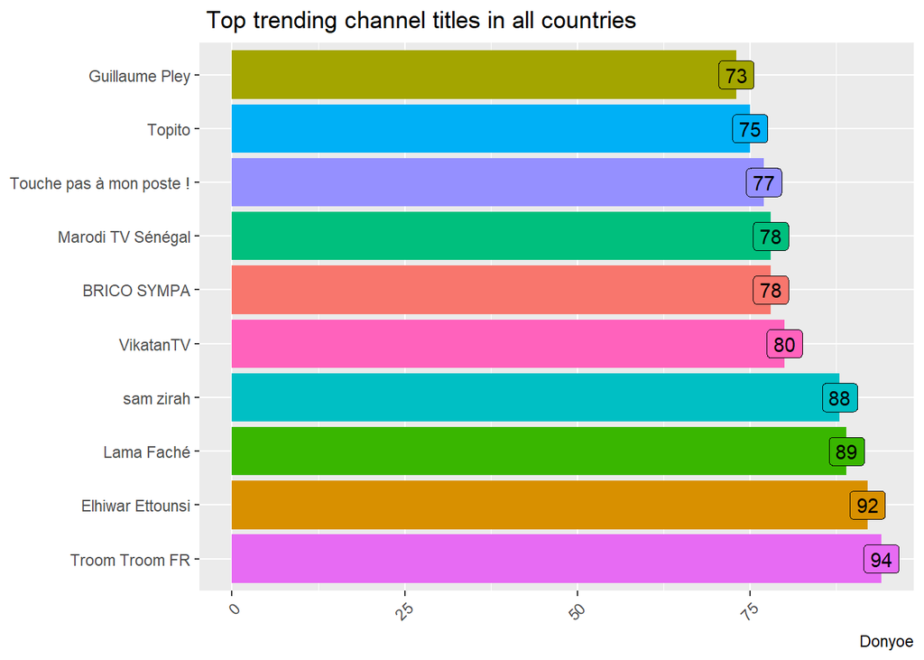

```r
ggplot(videos[,.N,by=channel_title][order(-N)][1:10],aes(reorder(channel_title,-N),N,fill=channel_title))+geom_bar(stat="identity")+geom_label(aes(label=N))+guides(fill="none")+theme(axis.text.x = element_text(angle = 45,hjust = 1))+  labs(caption="Donyoe",title=" Top trending channel titles in all countries")+

xlab(NULL)+ylab(NULL)+coord_flip()
```

# Title Bigrams

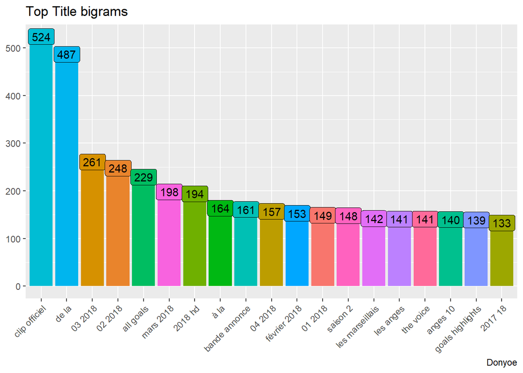

```r
biga <- unnest_tokens(videos,bigram, title, token = "ngrams", n = 2)
biga <- as.data.table(biga)

ggplot(biga[,.N,by=bigram][order(-N)][1:19],aes(reorder(bigram,-N),N,fill=bigram))+geom_bar(stat="identity")+geom_label(aes(label=N))+guides(fill="none")+theme(axis.text.x = element_text(angle = 45,hjust = 1))+  labs(caption="Donyoe",title="Top Title bigrams")+xlab(NULL)+ylab(NULL)
```

### Let us check out USA DATA

## Adding categories to the data frame

```r
usv = usv %>% mutate(category = case_when(
  category_id== '1' ~ 'Film and Animation',
  category_id== '2' ~ 'Autos and Vehicles',
  category_id== '10'~ 'Music',
  category_id== '15'~ 'Pets and Animals',
  category_id== '17'~ 'Sports',
  category_id== '18'~ 'Short Movies',
  category_id== '19'~ 'Travel and Events',
  category_id== '20'~'Gaming',
  category_id== '21'~'Videoblogging',
  category_id== '22'~ 'People and Blogs',
  category_id== '23'~ 'Comedy',
  category_id== '24'~ 'Entertainment',
  category_id== '25'~ 'News and Politics',
  category_id== '26'~ 'How to and Style',
  category_id== '27'~ 'Education',
  category_id== '28'~ 'Science and Technology',
  category_id== '29'~ 'Nonprofits & Activism',
  category_id== '30'~ 'Movies',
  category_id== '31'~ 'Anime/Animation',
  category_id== '32'~ 'Action/Adventure',
  category_id== '33'~ 'Classics',
  category_id== '34'~ 'Comedy',
  category_id== '35'~ 'Documentary',
  category_id== '36'~ 'Drama',
  category_id== '37'~ 'Family',
  category_id== '38'~ 'Foreign',
  category_id== '39'~ 'Horror',
  category_id== '40'~ 'Sci-Fi/Fantasy',
  category_id== '41'~ 'Thriller',
  category_id== '42'~ 'Shorts',
  category_id== '43'~ 'Shows',
  category_id== '44'~ 'Trailers'))
```

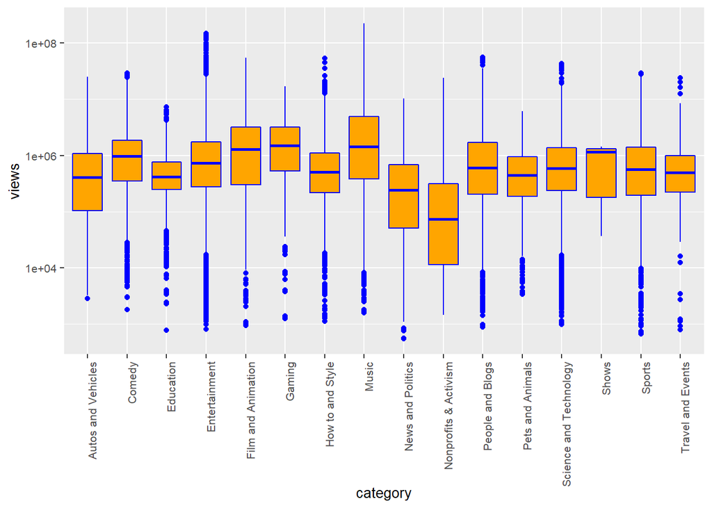

```r
ggplot(usv,aes(category,views))+geom_boxplot(fill = "orange",color = "blue")+scale_y_log10()+
  theme(text = element_text(size=10),axis.text.x = element_text(angle=90, hjust=1))
```

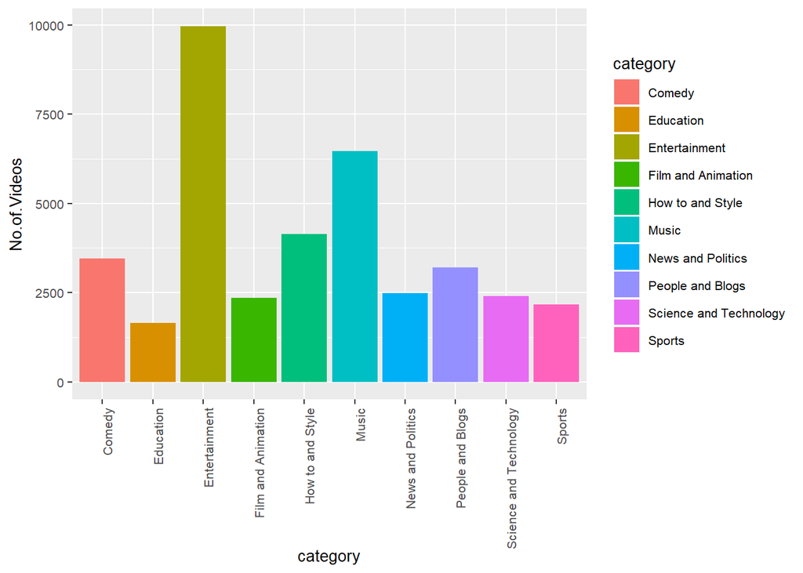

```r
US_Top10_Popular_Categories = usv %>% count(category)%>%
  arrange(desc(n))%>% head(10)%>%rename("No.of.Videos" = n)

ggplot(US_Top10_Popular_Categories,aes(category,No.of.Videos))+
  geom_bar(stat = "identity",aes(fill=category))+theme(text = element_text(size=10),
                                                       axis.text.x = element_text(angle=90, hjust=1))
```

## Top 10 popular channels in USA

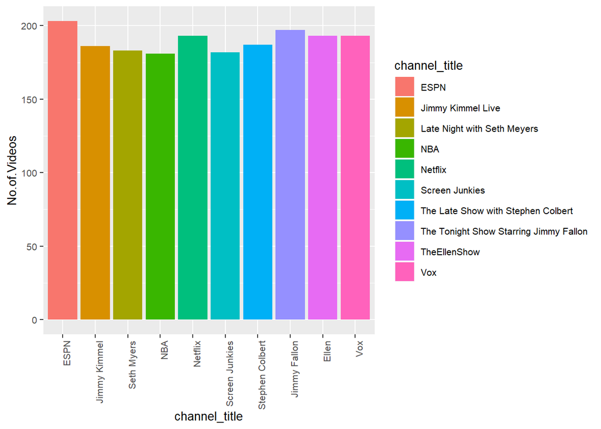

```r
US_Top10_Channels_with_most_trending_videos = usv %>% count(channel_title)%>%
  arrange(desc(n))%>% head(10)%>%rename("No.of.Videos" = n)

labels = c("ESPN","Jimmy Kimmel","Seth Myers","NBA","Netflix","Screen Junkies","Stephen Colbert","Jimmy Fallon","Ellen","Vox")

ggplot(US_Top10_Channels_with_most_trending_videos,aes(channel_title,No.of.Videos))+
  geom_bar(stat = "identity",aes(fill = channel_title ))+scale_x_discrete(labels = labels)+theme(text = element_text(size=10),
                                                                                                 axis.text.x = element_text(angle=90, hjust=1))
```

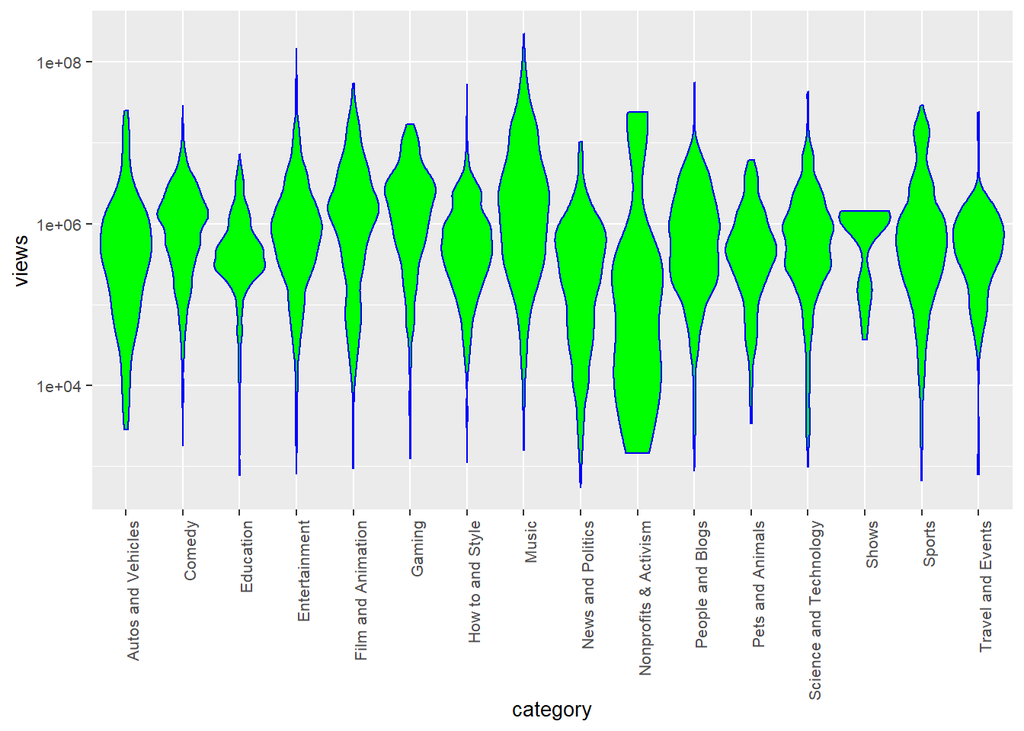

```r
ggplot(usv,aes(category,views))+geom_violin(scale = "width",fill = "green",color = "blue")+scale_y_log10()+
  theme(text = element_text(size=10),axis.text.x = element_text(angle=90, hjust=1))
```

## Top 10 Most liked videos in USA

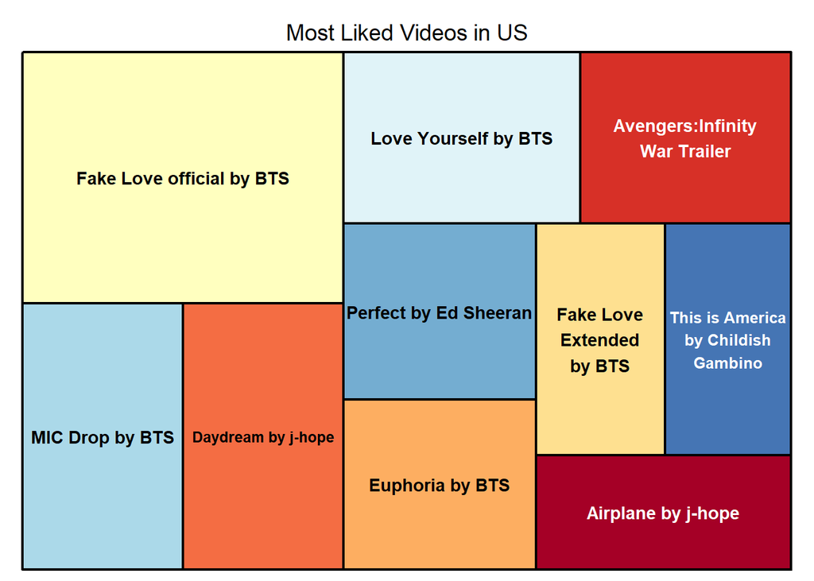

```r
US_Top10_most_liked_videos = usv %>% select(title,channel_title,likes) %>% distinct(title,.keep_all = TRUE) %>%
  mutate(Title = title)%>%arrange(desc(likes))%>% head(10)

US_Top10_most_liked_videos$Title = c("Fake Love official by BTS","MIC Drop by BTS","Daydream by j-hope","Love Yourself by BTS","Avengers:Infinity War Trailer","Perfect by Ed Sheeran","Euphoria by BTS","Fake Love Extended by BTS","This is America by Childish Gambino","Airplane by j-hope")

Map_US_most_liked = treemap(US_Top10_most_liked_videos,index = "Title",vSize = "likes",type = "index",title = "Most Liked Videos in US",palette="RdYlBu")
```

## Top 10 Most Viewed videos in USA

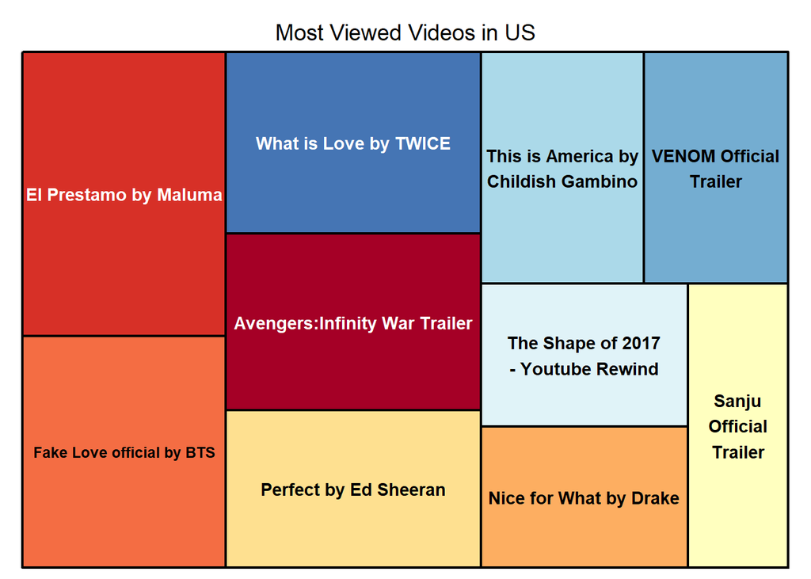

```r
US_Top10_most_viewed_videos = usv %>% select(title,channel_title,views,likes,category,comment_count) %>%
  distinct(title,.keep_all = TRUE) %>%mutate(Title = title)%>% arrange(desc(views))%>% head(10)

US_Top10_most_viewed_videos$Title = c("El Prestamo by Maluma","Fake Love official by BTS","What is Love by TWICE","Avengers:Infinity War Trailer","Perfect by Ed Sheeran","This is America by Childish Gambino","VENOM Official Trailer","The Shape of 2017 - Youtube Rewind","Nice for What by Drake","Sanju Official Trailer")

Map_US_most_viewed = treemap(US_Top10_most_viewed_videos,index = "Title",vSize = "views",type = "index",title = "Most Viewed Videos in US",palette="RdYlBu")
```

## Categories and their corresponding views,likes in USA

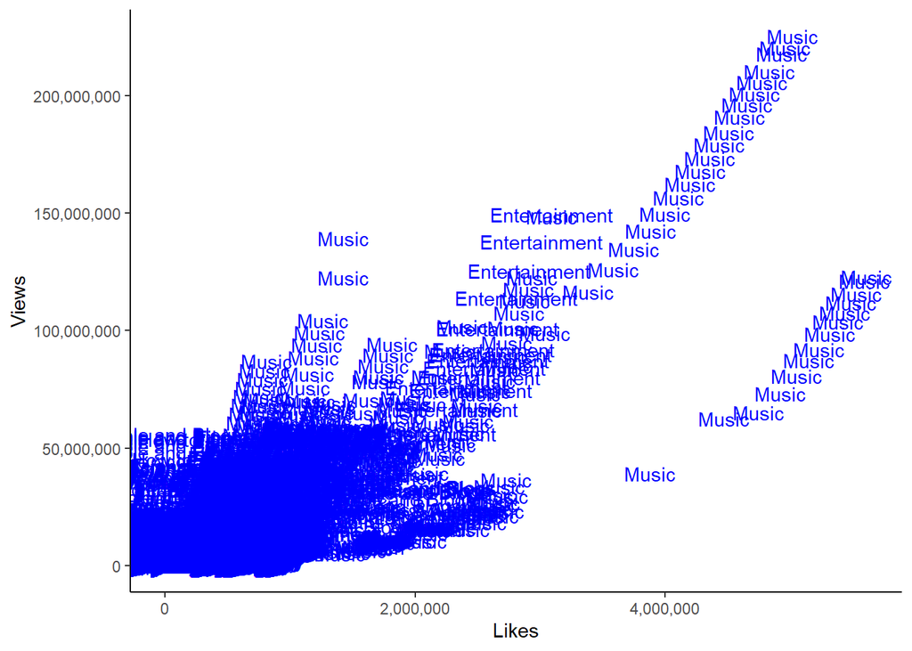

```r
ggplot(usv,aes(likes,views))+geom_text(aes(label = category),color= "blue",stat = "identity",check_overlap = FALSE)+theme_classic()+
  scale_x_continuous(name = 'Likes',labels = comma)+scale_y_continuous(name = 'Views',labels = comma)
```

## Channels and their deleted videos in USA

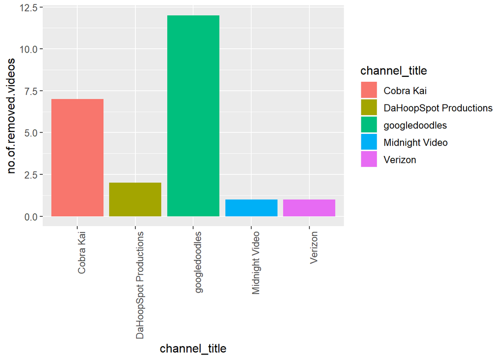

```r
US_channels_with_ErrororRemoved_videos = usv %>% filter(video_error_or_removed != 'False')%>%group_by(video_id)%>%
  count(channel_title) %>% rename("no.of.removed.videos" = n)

ggplot(US_channels_with_ErrororRemoved_videos,aes(channel_title,no.of.removed.videos))+
  geom_bar(stat = "identity",aes(fill = channel_title ))+theme(text = element_text(size=12),
                                                               axis.text.x = element_text(angle=90, hjust=1))
```

- We can see that a lot of the trending videos are music videos.

# Top Category ID

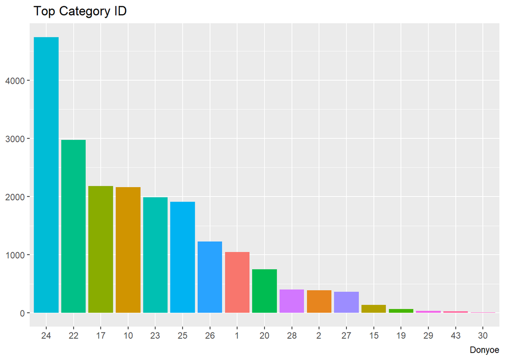

```r
ggplot(videos[,.N,by=category_id][order(-N)],aes(reorder(category_id,-N),N,fill=as.factor(category_id)))+geom_bar(stat="identity")+guides(fill="none")+labs(caption="Donyoe",title=" Top Category ID")+

xlab(NULL)+ylab(NULL)
```

### Let us consider Canada Data

## Adding categories to the data frame

```r
cav = cav %>% mutate(category = case_when(
  category_id== '1' ~ 'Film and Animation',
  category_id== '2' ~ 'Autos and Vehicles',
  category_id== '10'~ 'Music',
  category_id== '15'~ 'Pets and Animals',
  category_id== '17'~ 'Sports',
  category_id== '18'~ 'Short Movies',
  category_id== '19'~ 'Travel and Events',
  category_id== '20'~'Gaming',
  category_id== '21'~'Videoblogging',
  category_id== '22'~ 'People and Blogs',
  category_id== '23'~ 'Comedy',
  category_id== '24'~ 'Entertainment',
  category_id== '25'~ 'News and Politics',
  category_id== '26'~ 'How to and Style',
  category_id== '27'~ 'Education',
  category_id== '28'~ 'Science and Technology',
  category_id== '29'~ 'Nonprofits & Activism',
  category_id== '30'~ 'Movies',
  category_id== '31'~ 'Anime/Animation',
  category_id== '32'~ 'Action/Adventure',
  category_id== '33'~ 'Classics',
  category_id== '34'~ 'Comedy',
  category_id== '35'~ 'Documentary',
  category_id== '36'~ 'Drama',
  category_id== '37'~ 'Family',
  category_id== '38'~ 'Foreign',
  category_id== '39'~ 'Horror',
  category_id== '40'~ 'Sci-Fi/Fantasy',
  category_id== '41'~ 'Thriller',
  category_id== '42'~ 'Shorts',
  category_id== '43'~ 'Shows',
  category_id== '44'~ 'Trailers'))
```

## Views per Category in Canada

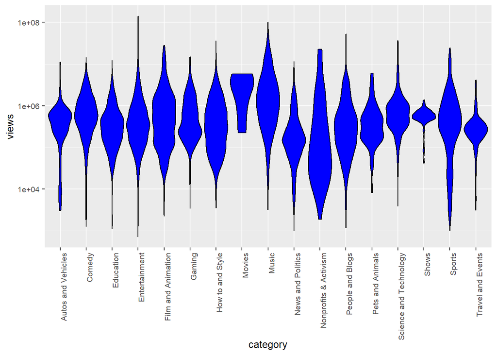

```r
ggplot(cav,aes(category,views))+geom_violin(scale = "width",fill = "blue",color = "black")+scale_y_log10()+
  theme(text = element_text(size=10),axis.text.x = element_text(angle=90, hjust=1))
```

## Top 10 popular Categories in Canada

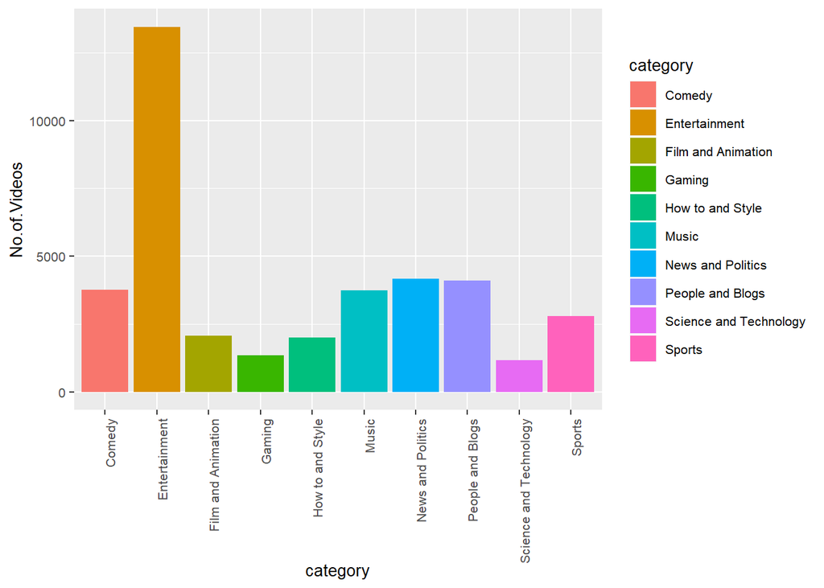

```r
CA_Top10_Popular_Categories = cav %>% count(category)%>%
  arrange(desc(n))%>% head(10)%>%rename("No.of.Videos" = n)

ggplot(CA_Top10_Popular_Categories,aes(category,No.of.Videos))+
  geom_bar(stat = "identity",aes(fill=category))+theme(text = element_text(size=10),
                                                       axis.text.x = element_text(angle=90, hjust=1))
```

## Top 10 Most liked videos in Canada

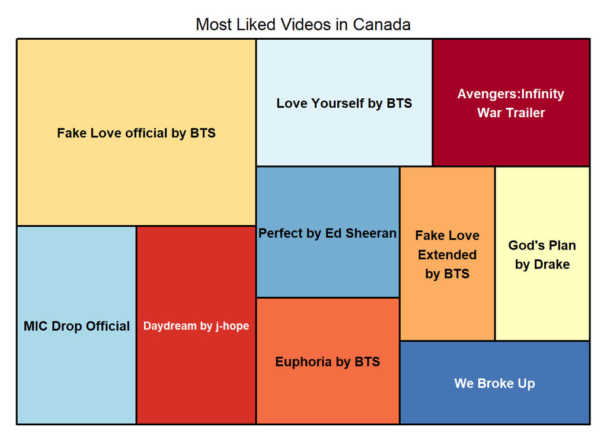

```r
CA_Top10_most_liked_videos = cav %>% select(title,channel_title,likes) %>%
  distinct(title,.keep_all = TRUE) %>% arrange(desc(likes))%>% head(10)

CA_Top10_most_liked_videos$Title = c("Fake Love official by BTS","MIC Drop Official","Daydream by j-hope","Love Yourself by BTS","Avengers:Infinity War Trailer","Perfect by Ed Sheeran","Euphoria by BTS","Fake Love Extended by BTS","God's Plan by Drake","We Broke Up")

Map_Canada_most_liked = treemap(CA_Top10_most_liked_videos,index = "Title",vSize = "likes",type = "index",title = "Most Liked Videos in Canada",palette="RdYlBu")
```

## Top 10 Most Viewed videos in Canada

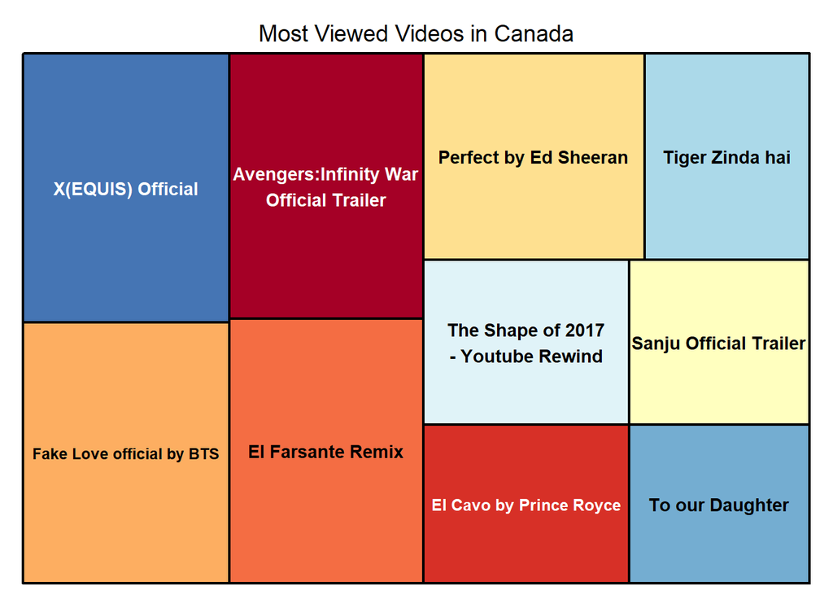

```r
CA_Top10_most_viewed_videos = cav %>% select(title,channel_title,views) %>%
  distinct(title,.keep_all = TRUE) %>% arrange(desc(views))%>% head(10)

CA_Top10_most_viewed_videos$Title = c("X(EQUIS) Official","Fake Love official by BTS","Avengers:Infinity War Official Trailer","El Farsante Remix","Perfect by Ed Sheeran","Tiger Zinda hai","The Shape of 2017 - Youtube Rewind","El Cavo by Prince Royce","Sanju Official Trailer","To our Daughter")

Map_Canada_most_viewed = treemap(CA_Top10_most_viewed_videos,index = "Title",vSize = "views",type = "index",title = "Most Viewed Videos in Canada",palette="RdYlBu")
```

### Great Britian Data

## Adding categories to the data frame

```r
gbv = gbv %>% mutate(category = case_when(
  category_id== '1' ~ 'Film and Animation',
  category_id== '2' ~ 'Autos and Vehicles',
  category_id== '10'~ 'Music',
  category_id== '15'~ 'Pets and Animals',
  category_id== '17'~ 'Sports',
  category_id== '18'~ 'Short Movies',
  category_id== '19'~ 'Travel and Events',
  category_id== '20'~'Gaming',
  category_id== '21'~'Videoblogging',
  category_id== '22'~ 'People and Blogs',
  category_id== '23'~ 'Comedy',
  category_id== '24'~ 'Entertainment',
  category_id== '25'~ 'News and Politics',
  category_id== '26'~ 'How to and Style',
  category_id== '27'~ 'Education',
  category_id== '28'~ 'Science and Technology',
  category_id== '29'~ 'Nonprofits & Activism',
  category_id== '30'~ 'Movies',
  category_id== '31'~ 'Anime/Animation',
  category_id== '32'~ 'Action/Adventure',
  category_id== '33'~ 'Classics',
  category_id== '34'~ 'Comedy',
  category_id== '35'~ 'Documentary',
  category_id== '36'~ 'Drama',
  category_id== '37'~ 'Family',
  category_id== '38'~ 'Foreign',
  category_id== '39'~ 'Horror',
  category_id== '40'~ 'Sci-Fi/Fantasy',
  category_id== '41'~ 'Thriller',
  category_id== '42'~ 'Shorts',
  category_id== '43'~ 'Shows',
  category_id== '44'~ 'Trailers'))
```

## Views per Category in Great Britian

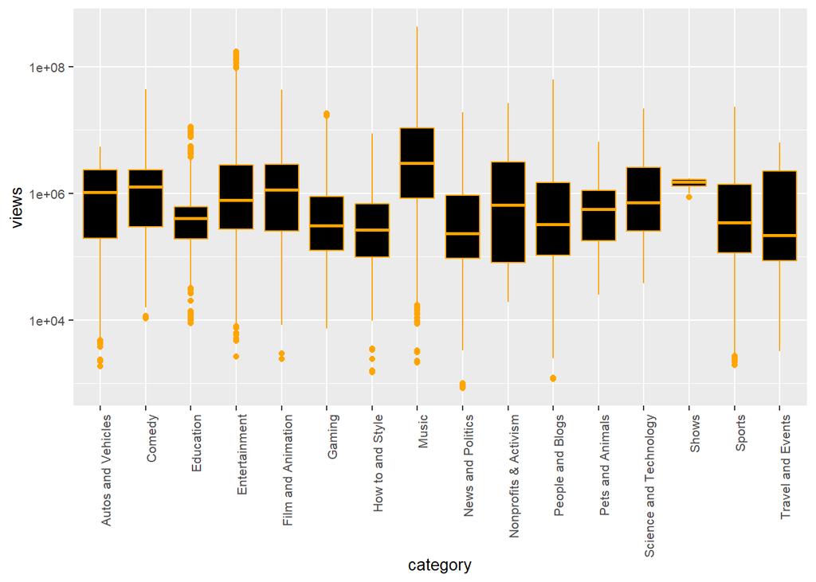

```r
ggplot(gbv,aes(category,views))+geom_boxplot(fill = "black",color = "orange")+scale_y_log10()+
  theme(text = element_text(size=10),axis.text.x = element_text(angle=90, hjust=1))
```

## Top 10 popular Categories in Great Britian

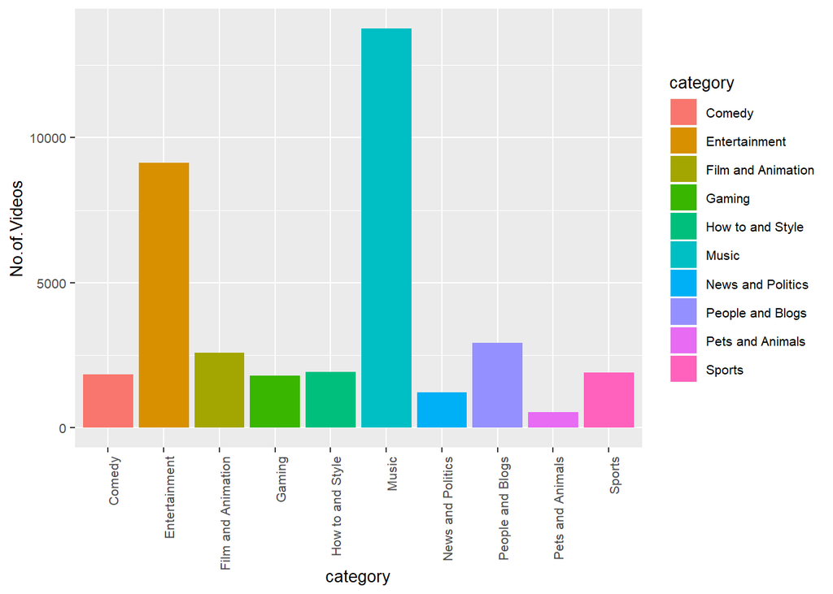

```r
GB_Top10_Popular_Categories = gbv %>% count(category)%>%
  arrange(desc(n))%>% head(10)%>%rename("No.of.Videos" = n)

ggplot(GB_Top10_Popular_Categories,aes(category,No.of.Videos))+
  geom_bar(stat = "identity",aes(fill=category))+theme(text = element_text(size=10),
                                                       axis.text.x = element_text(angle=90, hjust=1))
```

## Top 10 Most liked videos in Great Britian

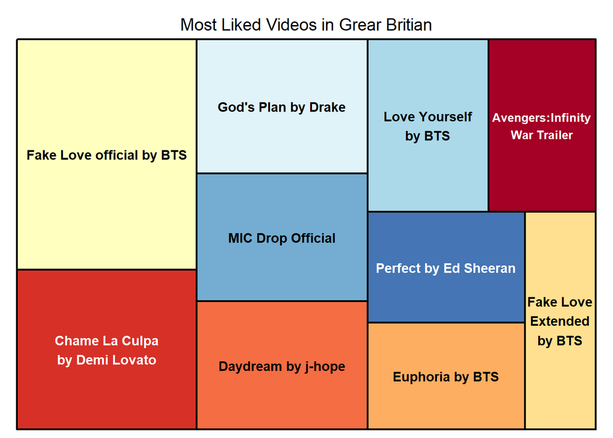

```r
GB_Top10_most_liked_videos = gbv %>% select(title,channel_title,likes) %>%
  distinct(title,.keep_all = TRUE) %>% arrange(desc(likes))%>% head(10)

GB_Top10_most_liked_videos$Title = c("Fake Love official by BTS","Chame La Culpa by Demi Lovato","God's Plan by Drake","MIC Drop Official","Daydream by j-hope","Love Yourself by BTS","Avengers:Infinity War Trailer","Perfect by Ed Sheeran","Euphoria by BTS","Fake Love Extended by BTS")

Map_GB_most_liked = treemap(GB_Top10_most_liked_videos,index = "Title",vSize = "likes",type = "index",title = "Most Liked Videos in Grear Britian",palette="RdYlBu")
```

## Top 10 Most Viewed videos in Great Britian

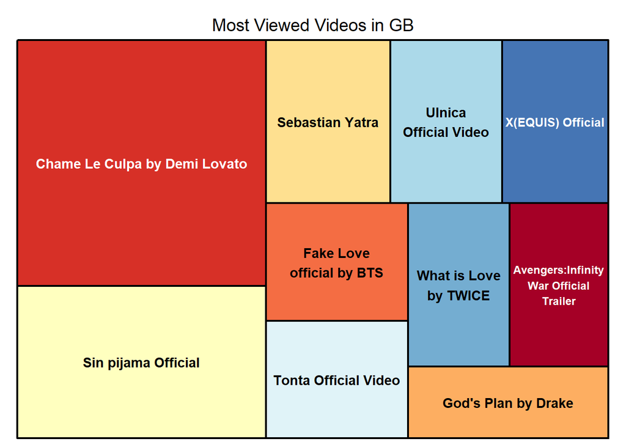

```r
GB_Top10_most_viewed_videos = gbv %>% select(title,channel_title,views) %>%
  distinct(title,.keep_all = TRUE) %>% arrange(desc(views))%>% head(10)

GB_Top10_most_viewed_videos$Title = c("Chame Le Culpa by Demi Lovato","Sin pijama Official","Sebastian Yatra","Ulnica Official Video","X(EQUIS) Official","Fake Love official by BTS","Tonta Official Video","What is Love by TWICE","Avengers:Infinity War Official Trailer","God's Plan by Drake")

Map_GB_most_viewed = treemap(GB_Top10_most_viewed_videos,index = "Title",vSize = "views",type = "index",title = "Most Viewed Videos in GB",palette="RdYlBu")
```

### France Data

## Adding categories to the data frame

```r
frv = frv %>% mutate(category = case_when(
  category_id== '1' ~ 'Film and Animation',
  category_id== '2' ~ 'Autos & Vehicles',
  category_id== '10'~ 'Music',
  category_id== '15'~ 'Pets and Animals',
  category_id== '17'~ 'Sports',
  category_id== '18'~ 'Short Movies',
  category_id== '19'~ 'Travel and Events',
  category_id== '20'~'Gaming',
  category_id== '21'~'Videoblogging',
  category_id== '22'~ 'People and Blogs',
  category_id== '23'~ 'Comedy',
  category_id== '24'~ 'Entertainment',
  category_id== '25'~ 'News and Politics',
  category_id== '26'~ 'How to and Style',
  category_id== '27'~ 'Education',
  category_id== '28'~ 'Science and Technology',
  category_id== '29'~ 'Nonprofits & Activism',
  category_id== '30'~ 'Movies',
  category_id== '31'~ 'Anime/Animation',
  category_id== '32'~ 'Action/Adventure',
  category_id== '33'~ 'Classics',
  category_id== '34'~ 'Comedy',
  category_id== '35'~ 'Documentary',
  category_id== '36'~ 'Drama',
  category_id== '37'~ 'Family',
  category_id== '38'~ 'Foreign',
  category_id== '39'~ 'Horror',
  category_id== '40'~ 'Sci-Fi/Fantasy',
  category_id== '41'~ 'Thriller',
  category_id== '42'~ 'Shorts',
  category_id== '43'~ 'Shows',
  category_id== '44'~ 'Trailers'))
```

## Views per Category in France

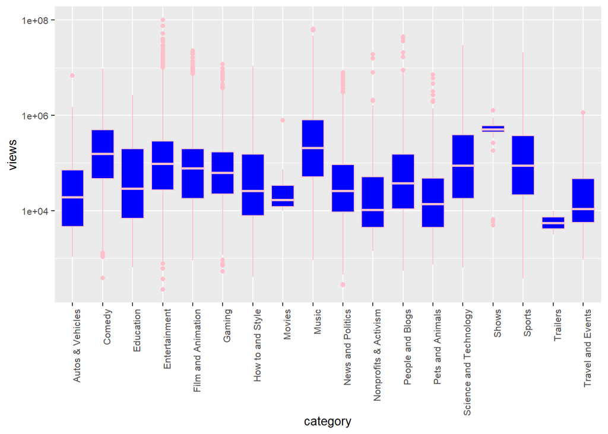

```r
ggplot(frv,aes(category,views))+geom_boxplot(fill = "blue",color = "pink")+scale_y_log10()+
  theme(text = element_text(size=10),axis.text.x = element_text(angle=90, hjust=1))
```

## Top 10 popular Categories in France

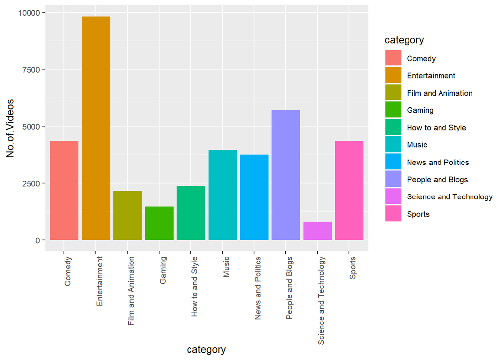

```r
FR_Top10_Popular_Categories = frv %>% count(category)%>%
  arrange(desc(n))%>% head(10)%>%rename("No.of.Videos" = n)

ggplot(FR_Top10_Popular_Categories,aes(category,No.of.Videos))+
  geom_bar(stat = "identity",aes(fill=category))+theme(text = element_text(size=10),
                                                       axis.text.x = element_text(angle=90, hjust=1))
```

## Top 10 Most liked videos in France

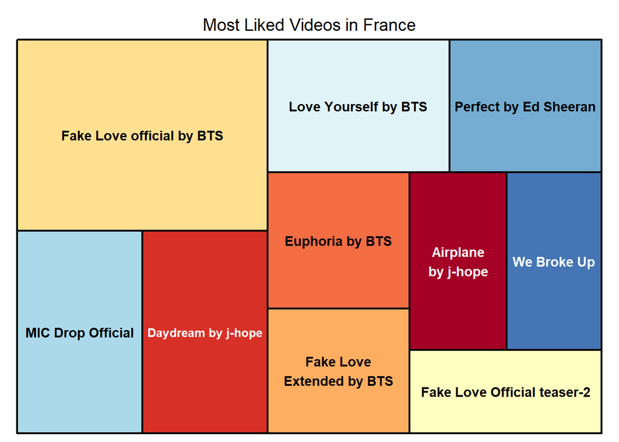

```r
FR_Top10_most_liked_videos = frv %>% select(title,channel_title,likes) %>%
  distinct(title,.keep_all = TRUE) %>% arrange(desc(likes))%>% head(10)

FR_Top10_most_liked_videos$Title = c("Fake Love official by BTS","MIC Drop Official","Daydream by j-hope","Love Yourself by BTS","Perfect by Ed Sheeran","Euphoria by BTS","Fake Love Extended by BTS","Airplane by j-hope","We Broke Up","Fake Love Official teaser-2")

Map_FR_most_liked = treemap(FR_Top10_most_liked_videos,index = "Title",vSize = "likes",type = "index",title = "Most Liked Videos in France",palette="RdYlBu")
```

## Top 10 Most Viewed videos in France

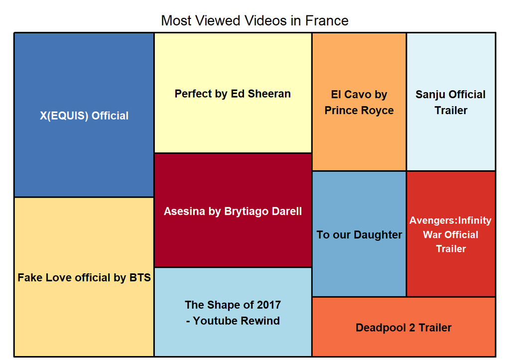

```r
FR_Top10_most_viewed_videos = frv %>% select(title,channel_title,views) %>%
  distinct(title,.keep_all = TRUE) %>% arrange(desc(views))%>% head(10)

FR_Top10_most_viewed_videos$Title = c("X(EQUIS) Official","Fake Love official by BTS","Perfect by Ed Sheeran","Asesina by Brytiago Darell","The Shape of 2017 - Youtube Rewind","El Cavo by Prince Royce","Sanju Official Trailer","To our Daughter","Avengers:Infinity War Official Trailer","Deadpool 2 Trailer")

Map_FR_most_viewed = treemap(FR_Top10_most_viewed_videos,index = "Title",vSize = "views",type = "index",title = "Most Viewed Videos in France",palette="RdYlBu")
```

### Germany Data

## Adding categories to the data frame

```r
gev = gev %>% mutate(category = case_when(
  category_id== '1' ~ 'Film and Animation',
  category_id== '2' ~ 'Autos & Vehicles',
  category_id== '10'~ 'Music',
  category_id== '15'~ 'Pets and Animals',
  category_id== '17'~ 'Sports',
  category_id== '18'~ 'Short Movies',
  category_id== '19'~ 'Travel and Events',
  category_id== '20'~'Gaming',
  category_id== '21'~'Videoblogging',
  category_id== '22'~ 'People and Blogs',
  category_id== '23'~ 'Comedy',
  category_id== '24'~ 'Entertainment',
  category_id== '25'~ 'News and Politics',
  category_id== '26'~ 'How to and Style',
  category_id== '27'~ 'Education',
  category_id== '28'~ 'Science and Technology',
  category_id== '29'~ 'Nonprofits & Activism',
  category_id== '30'~ 'Movies',
  category_id== '31'~ 'Anime/Animation',
  category_id== '32'~ 'Action/Adventure',
  category_id== '33'~ 'Classics',
  category_id== '34'~ 'Comedy',
  category_id== '35'~ 'Documentary',
  category_id== '36'~ 'Drama',
  category_id== '37'~ 'Family',
  category_id== '38'~ 'Foreign',
  category_id== '39'~ 'Horror',
  category_id== '40'~ 'Sci-Fi/Fantasy',
  category_id== '41'~ 'Thriller',
  category_id== '42'~ 'Shorts',
  category_id== '43'~ 'Shows',
  category_id== '44'~ 'Trailers'))
```

## Views per Category in Germany

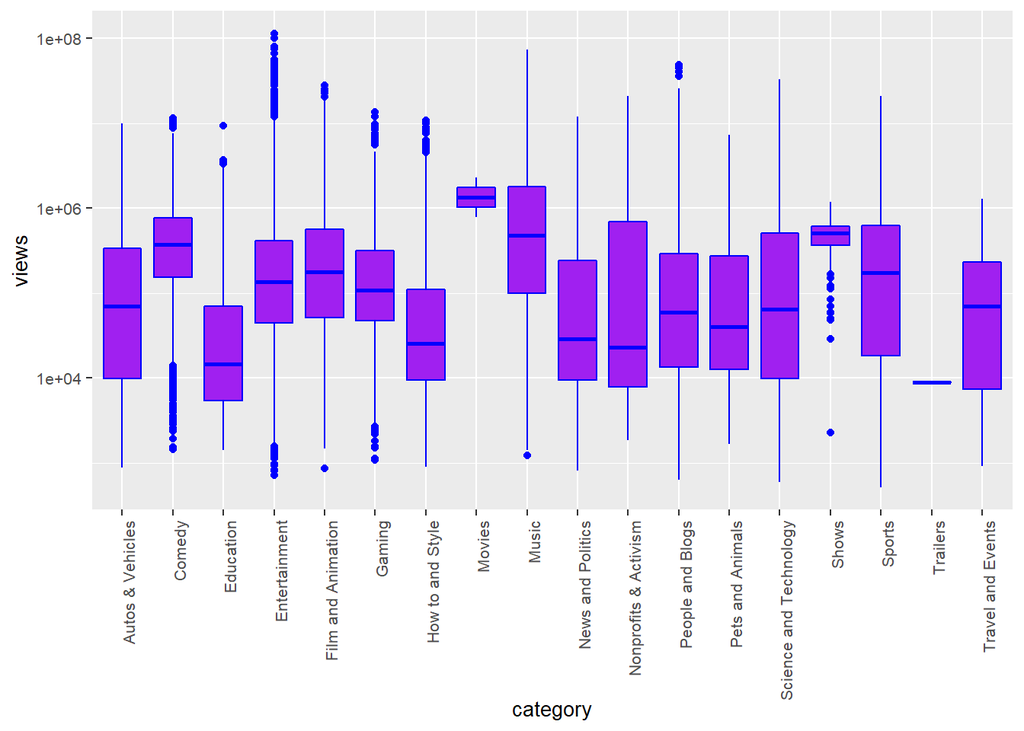

```r
ggplot(gev,aes(category,views))+geom_boxplot(fill = "purple",color = "blue")+scale_y_log10()+
  theme(text = element_text(size=10),axis.text.x = element_text(angle=90, hjust=1))
```

## Top 10 popular Categories in Germany

```r
GE_Top10_Popular_Categories = gev %>% count(category)%>%
  arrange(desc(n))%>% head(10)%>%rename("No.of.Videos" = n)
```

## Top 10 Most liked videos in Germany

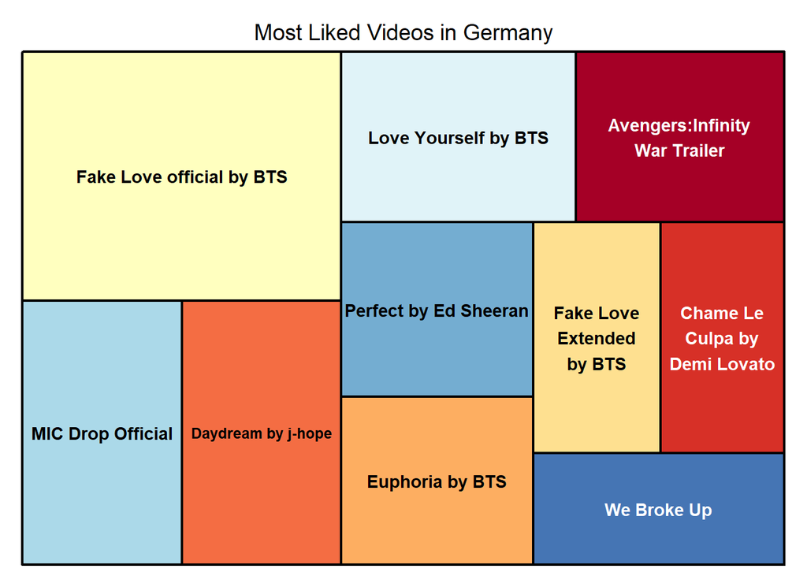

```r
GE_Top10_most_liked_videos = gev %>% select(title,channel_title,likes) %>%
  distinct(title,.keep_all = TRUE) %>% arrange(desc(likes))%>% head(10)

GE_Top10_most_liked_videos$Title = c("Fake Love official by BTS","MIC Drop Official","Daydream by j-hope","Love Yourself by BTS","Avengers:Infinity War Trailer","Perfect by Ed Sheeran","Euphoria by BTS","Fake Love Extended by BTS","Chame Le Culpa by Demi Lovato","We Broke Up")

Map_GE_most_liked = treemap(GE_Top10_most_liked_videos,index = "Title",vSize = "likes",type = "index",title = "Most Liked Videos in Germany",palette="RdYlBu")
```

## Top 10 Most Viewed videos in Germany

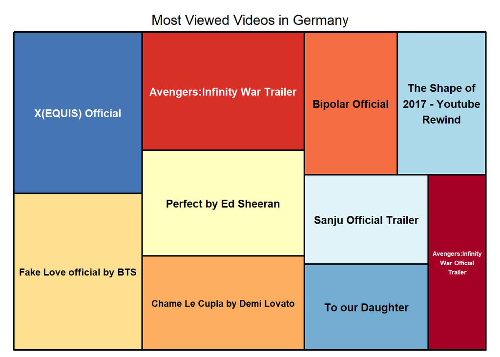

```r
GE_Top10_most_viewed_videos = gev %>% select(title,channel_title,views) %>%
  distinct(title,.keep_all = TRUE) %>% arrange(desc(views))%>% head(10)

GE_Top10_most_viewed_videos$Title = c("X(EQUIS) Official","Fake Love official by BTS","Avengers:Infinity War Trailer","Perfect by Ed Sheeran","Chame Le Cupla by Demi Lovato","Bipolar Official","The Shape of 2017 - Youtube Rewind","Sanju Official Trailer","To our Daughter","Avengers:Infinity War Official Trailer")

Map_GE_most_viewed = treemap(GE_Top10_most_viewed_videos,index = "Title",vSize = "views",type = "index",title = "Most Viewed Videos in Germany",palette="RdYlBu")
```

### Let’s see what’s common across regions

## Popular Categories across Countries

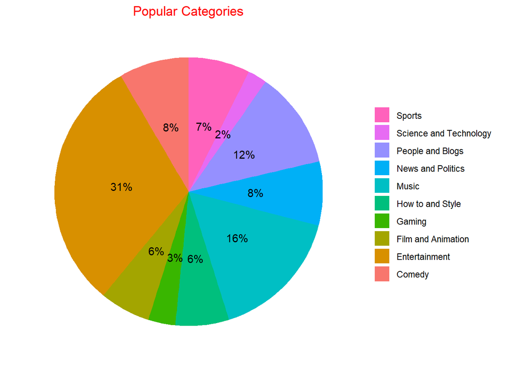

```r
Popular_categories = inner_join(full_join(US_Top10_Popular_Categories,CA_Top10_Popular_Categories,by = 'category'),
                                full_join(full_join(GB_Top10_Popular_Categories,FR_Top10_Popular_Categories,by = 'category'),
                                          GE_Top10_Popular_Categories,by = 'category'),by = 'category')
names(Popular_categories) = c("Category","USA" , "Canada" ,"Great Britian" ,"France","Germany")

df = gather(Popular_categories,country,videos,USA:Germany)

df1 = df %>% group_by(Category) %>% count(videos)%>%select(Category,videos)

df2 <- na.omit(df1)%>%
  group_by(Category) %>%
  summarise(volume = sum(videos)) %>%
  mutate(share=volume/sum(volume)*100.0) %>%
  arrange(desc(volume))

ggplot(df2,aes(x="", y=share, fill=Category))+
  geom_bar(width = 1, size = 1, stat = "identity")+
  coord_polar("y")+
  geom_text(aes(label = paste0(round(share), "%")),
            position = position_stack(vjust = 0.5)) +
  labs(x = NULL, y = NULL, fill = NULL,
       title = "Popular Categories") +
  guides(fill = guide_legend(reverse = TRUE)) +
  theme_classic() +
  theme(axis.line = element_blank(),
        axis.text = element_blank(),
        axis.ticks = element_blank(),
        plot.title = element_text(hjust = 0.5, color = "red"))
```

### Represenation of Countries and Categories with respect to no.of videos

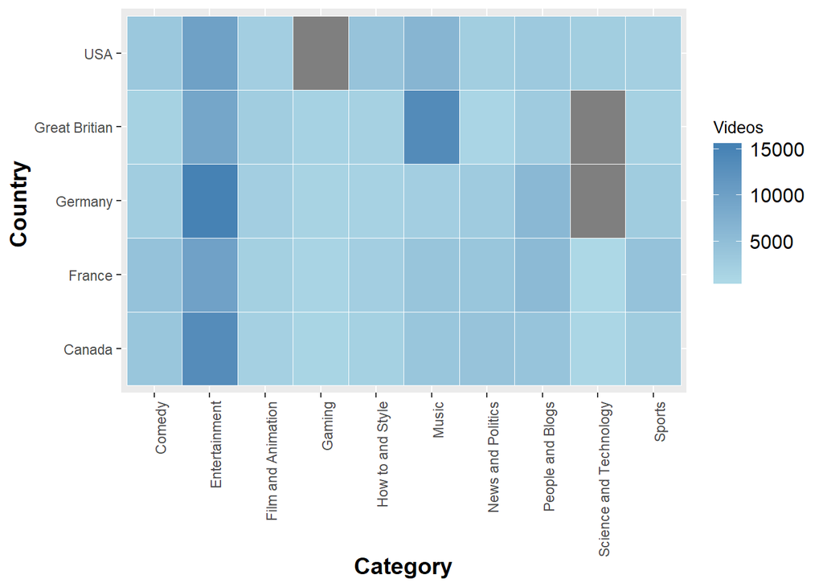

```r
ggplot(df,aes(Category,country))+geom_tile(aes(fill =videos),color = "white")+
  scale_fill_gradient(low = "light blue", high = "steelblue") +
  ylab("Country ") +
  xlab("Category") +
  theme(legend.title = element_text(size = 10),
        legend.text = element_text(size = 12),
        plot.title = element_text(size=16),
        axis.title=element_text(size=14,face="bold"),
        axis.text.x = element_text(angle = 90, hjust = 1)) +
  labs(fill = "Videos")
```

#Testing a bug

```r
corpus = Corpus(VectorSource(list(sample(videos$title,size=2000))))
corpus = tm_map(corpus, removePunctuation)
corpus = tm_map(corpus, content_transformer(tolower))
corpus = tm_map(corpus, removeNumbers)
corpus = tm_map(corpus, stripWhitespace)
corpus = tm_map(corpus, removeWords, stopwords('english'))
dtm_eap = DocumentTermMatrix(VCorpus(VectorSource(corpus[[1]]$content)))
freq_eap <- colSums(as.matrix(dtm_eap))
sentiments_eap = calculate_sentiment(names(freq_eap))
```

[output not shown]

[output cut: 3303 more lines]

[output not shown]

```r
sent_video = cbind(sentiments_eap, as.data.frame(freq_eap))
```

[output not shown]

```r
sent_video[contains(match = "uu",vars = sent_video$text),"freq_eap"] <- 0L
```

[output not shown]

```r
wordcloud(sent_video$text,sent_video$freq, min.freq=5,colors=brewer.pal(6,"Dark2"),random.order = F)
```

[output not shown]

###sentiment analysis

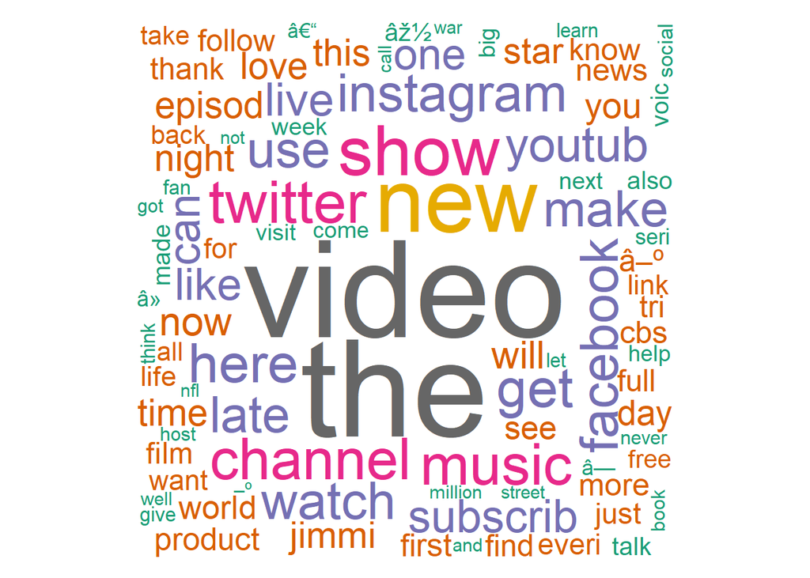

```r
set.seed(12)
text = array(sample(unique(usv$description),1000))
txt_corpus = Corpus(VectorSource(text))
# remove white space
tm_map = tm_map (txt_corpus, stripWhitespace)
# remove punctuations
tm_map = tm_map (tm_map, removePunctuation)
# to remove numbers
tm_map = tm_map (tm_map, removeNumbers)
# to remove stop words(like 'as' 'the' etc..)
tm_map = tm_map (tm_map, removeWords, stopwords("english"))
# remove URLs
removeURL = function(x) gsub("http[[:alnum:]]*", "", x)
tm_map = tm_map(tm_map, removeURL)
#to create stem document
tm_map = tm_map (tm_map, stemDocument)
#creating termdocumentmatrix
Matrix = TermDocumentMatrix(tm_map)
# converting into matrix
matrix_c = as.matrix (Matrix)
# frequency data
freq = sort (rowSums (matrix_c))
#creating wordcloud
tmdata = data.frame (words=names(freq), freq)
Word_Cloud = wordcloud (tmdata$words, tmdata$freq, max.words=200, min.freq=3, scale=c(7,.5), random.order=FALSE, colors=brewer.pal(8,"Dark2"))
```

- Hope you like it!